# Heteroskedasticity

EC 325: Econometrics

Prof. Caraher

Colby College

2026-10-29

## Previous Assumptions

- Units 7–8 made our **models** more flexible: dummies, logs, interactions
- GM 1–4 guarantee OLS is **unbiased**
- GM5 (**homoskedasticity**) makes our usual standard error formula valid
- Today: what happens when GM5 fails, and how to fix it

**Gauss-Markov Assumption 5 (Homoskedasticity)**

$$Var(\mu \mid x_1, x_2, \ldots, x_k) = \sigma^2$$

The error variance is **constant**: it doesn’t depend on the $x$’s.

## Is Horror the Best Investment in Hollywood?

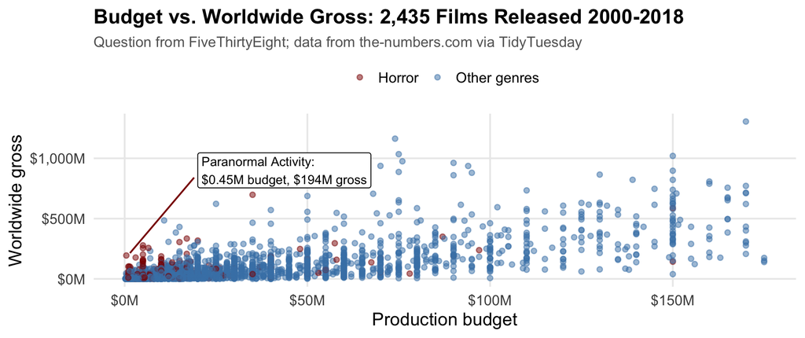

- Horror films gross **10.0×** their budget on average; dramas gross **2.9×**. Is that edge real?
- Grosses spread out as budgets grow: SD of $36M for budgets up to $10M vs. $214M above $100M

## Homoskedastic vs. Heteroskedastic

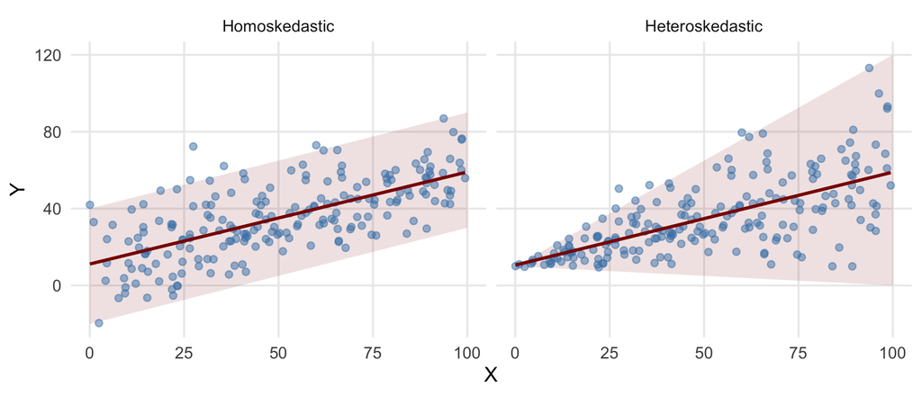

- **Heteroskedasticity** = the error variance changes with $x$. Here the spread “fans out”
- Same true line in both panels: $y = 10 + 0.5x$
- Movie grosses look like the right panel

## What Breaks?

Recall the three features of the sampling distribution of $\hat{\beta}_j$ (Unit 6):

|  | Question | Under heteroskedasticity |
| --- | --- | --- |
| **1. Center** | Where is it centered? | ✅ Still $E[\hat{\beta}_j] = \beta_j$: unbiasedness needs only GM 1–4 |
| **2. Spread** | How much does it vary? | ❌ The usual $se(\hat{\beta}_j)$ formula assumed GM5, so it is **wrong** |
| **3. Shape** | What distribution does it follow? | ✅ Still approximately normal in large samples (CLT) |

- The usual SEs are often **too small** (though not always)
- Too-small SEs → $t$-statistics too large → $p$-values too small
- So **we reject a true null hypothesis too often**

## Simulating the Problem

**Type I Error (Unit 6)**

Rejecting a **true** null hypothesis. At $\alpha = 0.05$, a working test does this 5% of the time.

We simulate data where the **true slope is zero** and count how often we (wrongly) reject $H_0: \beta_1 = 0$.

```r
n_sims <- 2000       # Number of simulated samples
n_obs <- 500         # Observations per sample
beta0_true <- 5      # True intercept
beta1_true <- 0      # True slope (THE NULL IS TRUE!)
```

Run 2,000 regressions under each scenario:

- **Homoskedastic**: SD of the error $= 10$ at every $x$
- **Heteroskedastic**: SD of the error $= 0.15x^2$, so it grows with $x$

## One Simulated Sample of Each

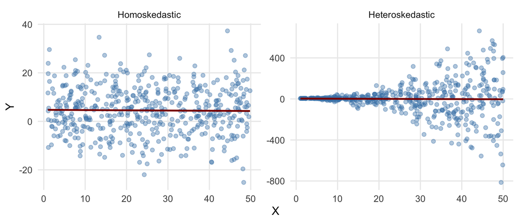

True $\beta_1 = 0$ in both panels. On the right, the spread fans out as $x$ grows (note the different $y$-axes).

## Homoskedasticity: The Usual SE Works

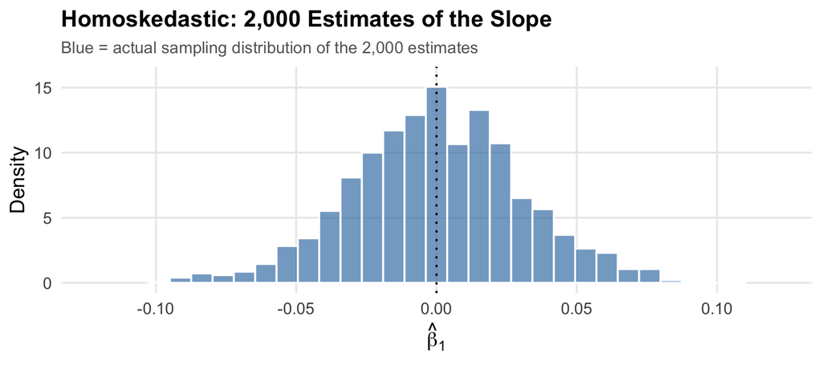

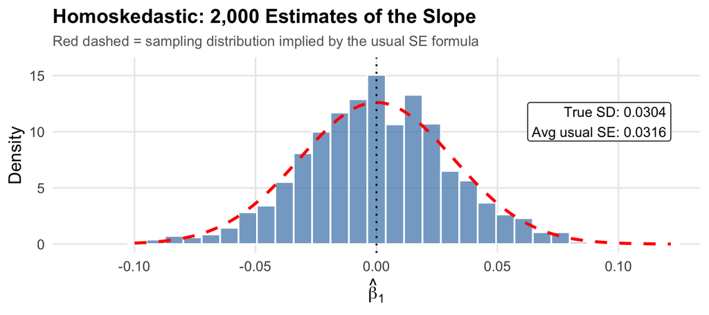

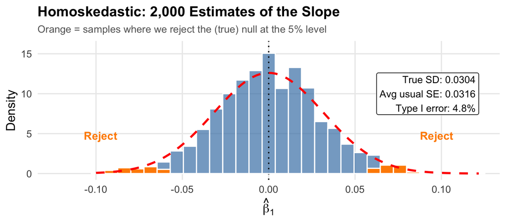

Red matches blue: the usual SE gets the spread right.

We wrongly reject $H_0: \beta_1 = 0$ in 4.8% of samples: on target.

## Heteroskedasticity: The Usual SE Is Too Small

**Predict:** with heteroskedasticity and the usual SEs, how often will we falsely reject: 5%, 10%, or 25%?

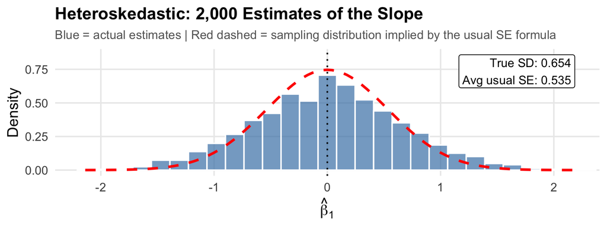

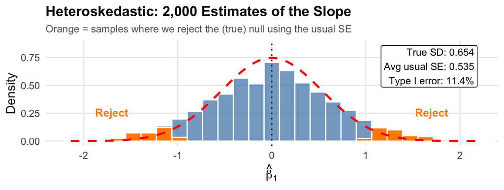

The usual SE is 18% too small: red is narrower than blue.

We wrongly reject $H_0: \beta_1 = 0$ in 11.4% of samples: double the 5% target.

## The Fix: Robust Standard Errors

In a simple regression, we can write both formulas the same way:

$$\text{Usual (Unit 6):} \quad se(\hat{\beta}_1)^2 = \frac{\sum_{i=1}^{n} (x_i - \bar{x})^2 \, \hat{\sigma}^2}{SST_x^2} = \frac{\hat{\sigma}^2}{SST_x}$$

$$\text{Robust:} \quad se(\hat{\beta}_1)^2 = \frac{\sum_{i=1}^{n} (x_i - \bar{x})^2 \, (\hat{\mu}_i)^2}{SST_x^2}$$

- The **only** difference: the usual formula gives every observation the **same** error variance, $\hat{\sigma}^2 = SSR/(n-2)$. The robust formula uses each observation’s **own** squared residual, $(\hat{\mu}_i)^2$
- If errors are bigger where $x$ is far from $\bar{x}$, the usual formula **averages that away**. The robust formula picks it up
- Also called **heteroskedasticity-robust** or **White** standard errors

## Why the Usual SE Is Too Small: The Movies

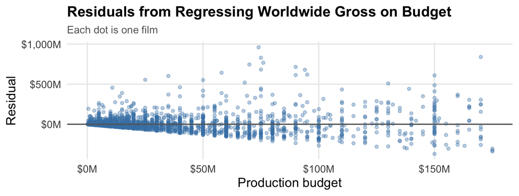

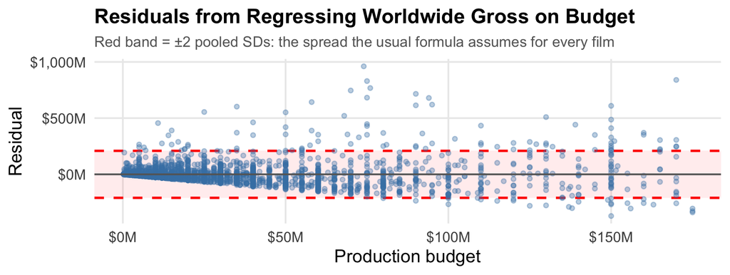

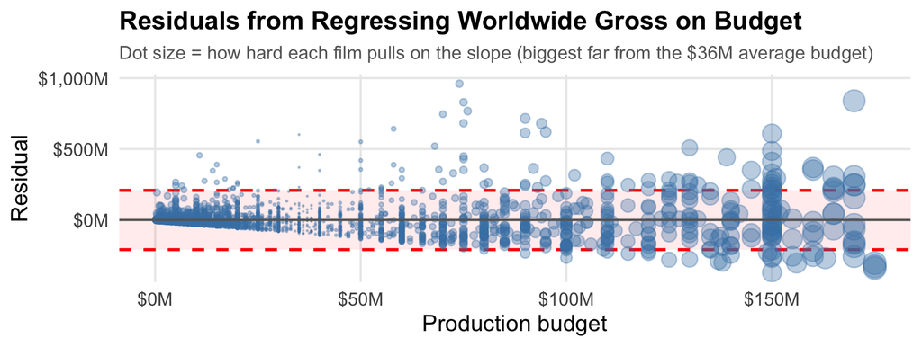

Residuals fan out: big-budget films miss by far more.

Outside the band: 34% of films over $100M, but only 0.6% under $10M.

The big dots pull hardest on the slope *and* miss the most: robust SE 0.099 vs. usual 0.057.

## Robust SEs Match the Actual Spread

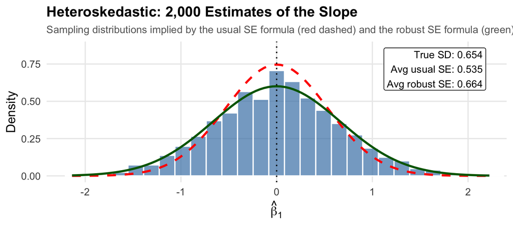

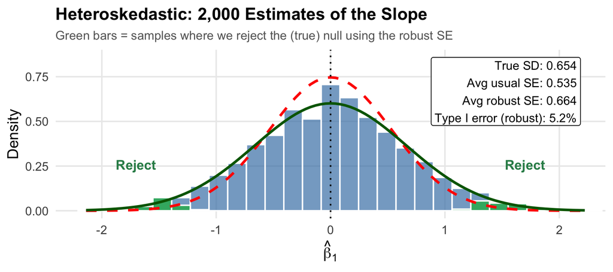

The green curve (robust SE) matches the actual spread of the estimates.

With robust SEs, we wrongly reject in 5.2% of samples, back near the 5% target.

## Type I Error Rates

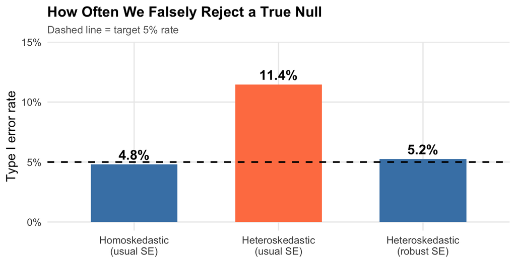

Robust SEs bring the false-positive rate back to about 5%.

## Robust SEs in R: Back to the Movies

From now on we use `feols()` from the **fixest** package: the same OLS estimates as `lm()`, and robust SEs take one argument.

```r
library(fixest)

m_usual  <- feols(worldwide_gross ~ budget, data = movies)
m_robust <- feols(worldwide_gross ~ budget, data = movies, vcov = "HC1")
```

|  | Usual SE | Robust SE |
| --- | --- | --- |
| (Intercept) | -0.837 | -0.837 |
|  | (2.946) | (2.567) |
| budget | 2.740*** | 2.740*** |
|  | (0.057) | (0.099) |
| Num.Obs. | 2435 | 2435 |

* p < 0.1, ** p < 0.05, *** p < 0.01

Same coefficient (each $1 of budget goes with $2.74 of worldwide gross), but the robust SE is 75% larger. The usual SE **overstated our precision**.

## Is Horror’s Edge Real?

Regress each film’s return (worldwide gross ÷ budget) on genre dummies, with drama as the baseline (Unit 7):

```r
movies <- movies |> mutate(genre = relevel(factor(genre), ref = "Drama"))

m_genre_usual  <- feols(roi ~ genre, data = movies)
m_genre_robust <- feols(roi ~ genre, data = movies, vcov = "HC1")
```

| Genre | Gap vs. drama | Usual SE | Robust SE | Usual t | Robust t |
| --- | --- | --- | --- | --- | --- |
| Action | -0.40 | 0.66 | 0.21 | -0.60 | -1.88 |
| Adventure | 0.09 | 0.66 | 0.22 | 0.14 | 0.41 |
| Comedy | 0.11 | 0.55 | 0.30 | 0.21 | 0.38 |
| Horror | 7.01 | 0.81 | 2.28 | 8.64 | 3.08 |

- **Horror:** the robust SE is 2.8 times as large, so $t$ falls from 8.6 to 3.1. The edge is still significant, but far less certain
- **Action:** the robust SE is *smaller*, 0.32 times the usual SE. The usual formula pools horror’s wild returns into one $\hat{\sigma}^2$ for **every** genre; the robust formula uses each film’s own $(\hat{\mu}_i)^2$

## What If There’s No Heteroskedasticity?

Is there a **cost** to using robust SEs when we don’t need them? Back to the homoskedastic simulation, which computed both SEs each time:

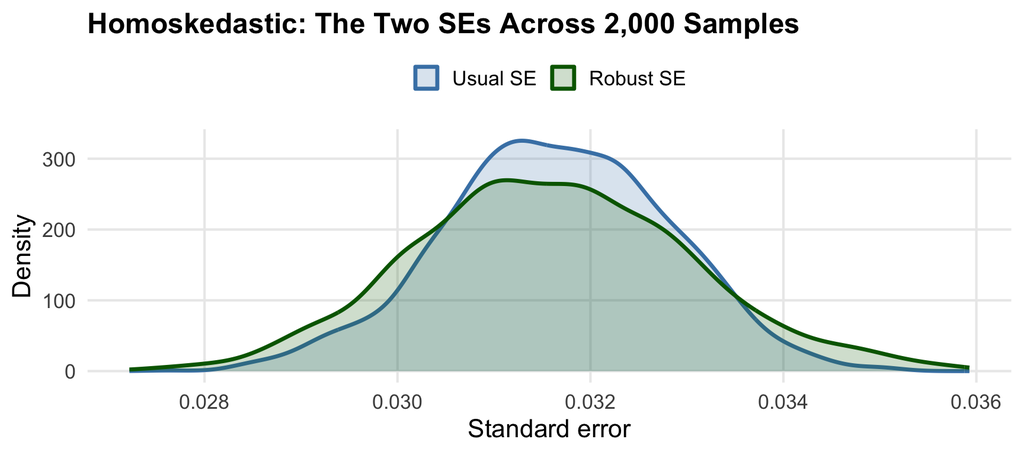

## The Cost Is Small

- **Same center:** the average usual SE is 0.0316; the average robust SE is 0.0316
- **A bit noisier:** robust SEs vary 24% more from sample to sample, because they use each $(\hat{\mu}_i)^2$ instead of one pooled $\hat{\sigma}^2$
- **Type I error:** 4.8% (usual) vs. 4.8% (robust), both about 5%

Small cost when unnecessary. Large benefit when needed. **Use robust SEs by default.**

## Summary

1. **Heteroskedasticity**: the error variance changes with $x$. It’s common: movie grosses spread out as budgets grow
2. $\hat{\beta}$ is still **unbiased** (center ✅), but the usual SEs are **wrong** (spread ❌)
3. Wrong SEs → too many false positives: 11.4% instead of 5% in our simulation
4. **Robust SEs** replace the pooled $\hat{\sigma}^2$ with each observation’s own $(\hat{\mu}_i)^2$
5. Using robust SEs when they aren’t needed costs almost nothing

**Bottom line**: always use `vcov = "HC1"` in `feols()`. In Unit 10 (binary outcomes), heteroskedasticity is guaranteed, so you’ll use this every time.